# Projekt Podstawy języka R - Dokumentacja

Autorzy: Natalia Cheba, Michał Sosna

Data sprawozdania: 05-06-2020

## Wprowadzenie

Celem projektu jest eksploracja danych o wywiadach przeprowadzonych w programie The Daily Show w latach 1999-2015.

## Czyszczenie danych

Zamiana na 3 kolumny - rozdzielenie daty

```r
guests<-separate(guests, col = c("show"), into = c("year", "month", "day"), sep = "-", extra = "merge")
```

Zmiana podobnych zmiennych

```r
guests$group[guests$group == "media"] <- "Media"
```

Zamiana na odpowiednie typy zmiennych

```r
guests$year <-as.numeric(guests$year)
guests$month <-as.numeric(guests$month)
guests$day <-as.numeric(guests$day)
guests$group <-as.factor(guests$group)
```

## Seasons

Stworzenie dodatkowej kolumny season na podstawie miesięcy

```r
guests$season[guests$month %in% c(12,1,2)] <- 'winter'
guests$season[guests$month %in% c(6,7,8)] <- 'summer'
guests$season[guests$month %in% c(9,10,11)] <- 'autumn'
guests$season[guests$month %in% c(3,4,5)] <- 'spring'
```

## Special Events

Znalezienie specjalnych eventów i zapisanie ich do nowej zmiennej

```r
specialEvents <- daily_show_guests
specialEvents <- specialEvents %>% filter(is.na(google_knowledge_occupation))
specialEvents <- specialEvents[specialEvents$raw_guest_list != "None"
                               & specialEvents$raw_guest_list != "none"
                               & specialEvents$raw_guest_list != "no guest"
                               & specialEvents$raw_guest_list != "no Guest"
                               & specialEvents$raw_guest_list != "No guest"
                               & specialEvents$raw_guest_list != "No Guest", ]
specialEvents <- specialEvents[,c(3,5)]
specialEvents
```

```
## # A tibble: 15 x 2
##    show       raw_guest_list
##    <date>     <chr>
##  1 1999-12-15 Greatest Millennium Special
##  2 1999-07-21 Third Anniversary Special
##  3 1999-08-30 The Daily Show Summer Spectacular
##  4 2000-11-20 Tales of Survival with Vance DeGeneres
##  5 2000-07-19 Fourth Anniversary Special
##  6 2000-07-31 Campaign Trail to the Road to the White House Mo Rocca, Vance DeG~
##  7 2002-10-14 Road to Washington Special
##  8 2002-05-23 Matt Walsh Goes To Hawaii
##  9 2003-11-24 Who are the Daily Show? Special
## 10 2003-05-26 Iraq - A Look Baq (or how we learned to stop reporting and love t~
## 11 2003-05-26 Iraq - A Look Baq (or how we learned to stop reporting and love t~
## 12 2003-06-08 Looking Beyond The Show
## 13 2003-09-01 I'm a Correspondent, Please Don't Fire Me!
## 14 2008-11-04 Indecision 2008 Live Election Night Special
## 15 2012-11-06 Election Night: This Ends Now
```

## Analiza imion

Filtrowanie

```r
guests2<-guests %>% filter(!is.na(google_knowledge_occupation))
guests2 <- guests2[guests2$raw_guest_list != "(None)"
                   & guests2$raw_guest_list != "none"
                   & guests2$raw_guest_list != "(no guest)"
                   & guests2$raw_guest_list != "none"
                   & guests2$raw_guest_list != "No guest"
                   & guests2$raw_guest_list != "None", ]
```

Usunięcie z nowego zbioru rekordów zawierającej tytuły, nazwy zespołów i podwójne imiona

```r
#przypisanie do nowej zmiennej
guests3 <- guests2 %>% filter(str_detect(guests2$raw_guest_list, ' & ') | str_detect(guests2$raw_guest_list, ' and ') | str_detect(guests2$raw_guest_list, ', ' ) | str_detect(guests2$raw_guest_list, 'Jr.' ) | str_detect(guests2$raw_guest_list, 'Dr. ' ) | str_detect(guests2$raw_guest_list, 'Rep.' ) | str_detect(guests2$raw_guest_list, 'Sen.' ) | str_detect(guests2$raw_guest_list, 'Senator' )| str_detect(guests2$google_knowledge_occupation, 'band' )| str_detect(guests2$raw_guest_list, 'Admiral' ) | str_detect(guests2$raw_guest_list, 'President' ))
#usuwanie
guests2 <- guests2 %>% filter(!(str_detect(guests2$raw_guest_list, ' & ') | str_detect(guests2$raw_guest_list, ' and ') | str_detect(guests2$raw_guest_list, ', ' ) | str_detect(guests2$raw_guest_list, 'Jr.' ) | str_detect(guests2$raw_guest_list, 'Dr. ' ) | str_detect(guests2$raw_guest_list, 'Rep.' ) | str_detect(guests2$raw_guest_list, 'Sen.' ) | str_detect(guests2$raw_guest_list, 'Senator' )| str_detect(guests2$google_knowledge_occupation, 'band' )| str_detect(guests2$raw_guest_list, 'Admiral' ) | str_detect(guests2$raw_guest_list, 'President' )))
```

Rozdzielenie na imię i nazwisko

```r
guests2 <- separate(guests2, col = c("raw_guest_list"), into = c("imie", "nazwisko"), sep = " ", extra = "merge")
```

Przeniesienie do nowej ramki danych osób, które mogą być jako zespół - jednoczłonowe

```r
guests4 <- guests2 %>% filter(is.na(nazwisko))
guests2 <- guests2 %>% filter(!(is.na(nazwisko)))
```

## Tytuły

Znalezienie tytułów (Admiral, Sen., Senator, President, Dr. i Rep.) i usunięcie ich ze zbioru

```r
tytul <- guests3 %>% filter(str_detect(guests3$raw_guest_list, 'Sen.' ) | str_detect(guests3$raw_guest_list, 'Senator' )| str_detect(guests3$raw_guest_list, 'Admiral' ) | str_detect(guests3$raw_guest_list, 'President' )| str_detect(guests3$raw_guest_list, 'Dr. ') | str_detect(guests3$raw_guest_list, 'Rep. '))

guests3 <- guests3 %>% filter(!(str_detect(guests3$raw_guest_list, 'Sen.' ) | str_detect(guests3$raw_guest_list, 'Senator' )| str_detect(guests3$raw_guest_list, 'Admiral' ) | str_detect(guests3$raw_guest_list, 'President' )| str_detect(guests3$raw_guest_list, 'Dr. ' ) | str_detect(guests3$raw_guest_list, 'Rep. ')))
```

Rozdzielenie kolumny na tytuł, imię i nazwisko

```r
tytul <- separate(tytul, col = c("raw_guest_list"), into = c("tytul", "imie", "nazwisko"), sep = " ", extra = "merge")
```

Zamiana Sen. na Senator

```r
tytul$tytul[tytul$tytul == "Sen."] <- "Senator"
```

Wykres ilości tytułów w zbiorze

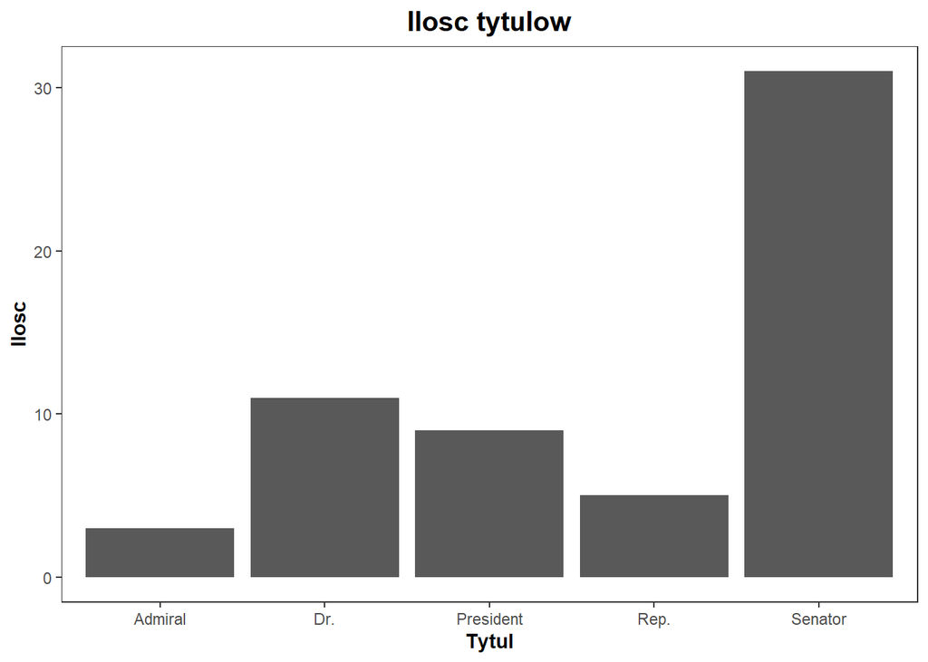

```r
tytul %>% group_by(tytul) %>% summarise( ilosc = n()) %>% ggplot(aes(x=tytul, y= ilosc)) + geom_col() +xlab("Tytul") + ylab("Ilosc") +
   ggtitle("Ilosc tytulow")+
   theme_test() +
   theme(plot.title = element_text(size = 15, hjust=0.5, face= 'bold', margin = ))+
   theme(axis.title.x = element_text( face="bold"))+
   theme(axis.title.y= element_text( face="bold"))
```

Na podstawie danych można stwierdzić, że wśród osób pełniących ważne funkcje państwowe, bądź posiadające tytuły naukowe, najwięcej razy w programie gościły osoby będące senatorami. Na drugim miejscu byli to doktorzy, a na trzecim prezydenci.

## Osoby z przedrostkiem Jr.

Wydzielenie do nowej ramki danych Jr.

```r
Juniory <- guests3 %>% filter(str_detect(guests3$raw_guest_list, 'Jr.'  ))
guests3 <- guests3 %>% filter(!(str_detect(guests3$raw_guest_list, 'Jr.'  )))
Juniory <- separate(Juniory, col = c("raw_guest_list"), into = c("imie", "nazwisko", "koncowka"), sep = " ", extra = "merge")
```

Wykres najpopularniejszych imion wsród Jr.

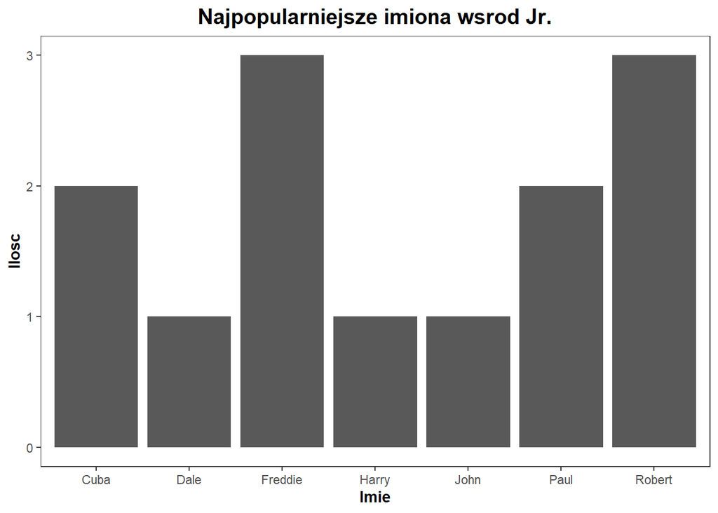

```r
Juniory %>% group_by(imie) %>% summarise( ilosc = n()) %>% ggplot(aes(x=imie, y= ilosc)) + geom_col() +xlab("Imie") + ylab("Ilosc") +
   ggtitle("Najpopularniejsze imiona wsrod Jr.")+
   theme_test() +
   theme(plot.title = element_text(size = 15, hjust=0.5, face= 'bold', margin = ))+
   theme(axis.title.x = element_text( face="bold"))+
   theme(axis.title.y= element_text( face="bold"))
```

Wśród osób posiadających w nazwisku przedrostek “Jr.” najwięcej z nich ma na imię Freddie, bądź Robert. Nie przynosi nam to żadnej konkretnej informacji, jednak zazwyczaj jest to tradycja praktykowana w konserwatywnych rodzinach. Posiadając większy zbiór danych można by było określić jakie najczęściej męskie imiona występują w konserwatywnych rodzinach w Stanach Zjednoczonych.

## Podwójne imiona

Znalezienie podwójnych imion

```r
Andy <- guests3 %>% filter(str_detect(guests3$raw_guest_list, ' & ' )   | str_detect(guests3$raw_guest_list, 'and' ))
guests3 <- guests3 %>% filter(!(str_detect(guests3$raw_guest_list, ' & ' )   | str_detect(guests3$raw_guest_list, 'and' )))
```

Wykres ilości z których była więcej niż jedna gwiazda

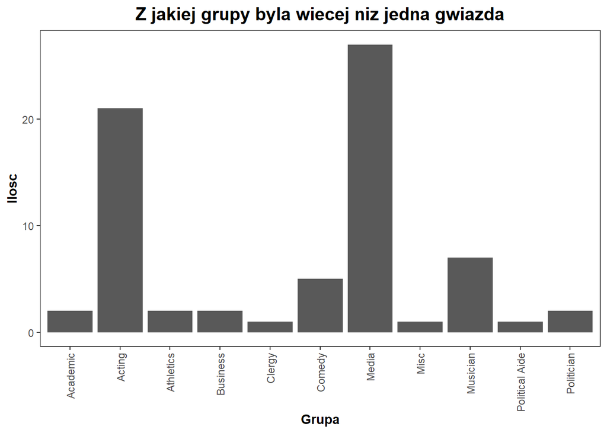

```r
Andy%>% group_by(group) %>% summarise( ilosc = n()) %>% ggplot(aes(x=group, y= ilosc)) + geom_col() +xlab("Grupa") + ylab("Ilosc") +
   ggtitle("Z jakiej grupy byla wiecej niz jedna gwiazda")+
   theme_test() +
   theme(plot.title = element_text(size = 15, hjust=0.5, face= 'bold', margin = ))+
   theme(axis.title.x = element_text( face="bold"))+
   theme(axis.title.y= element_text( face="bold"))  +  theme(axis.text.x = element_text(angle = 90, hjust = 1, vjust = 0.5))
```

Na podstawie analizy dziedziny, jaką zajmuje się osoba udzielająca wywiadu, można stwierdzić, że najbardziej popularni są aktorzy i osoby należące do grupy “Media”.

Wykres ilości w którym roku była więcej niż jedna gwiazda

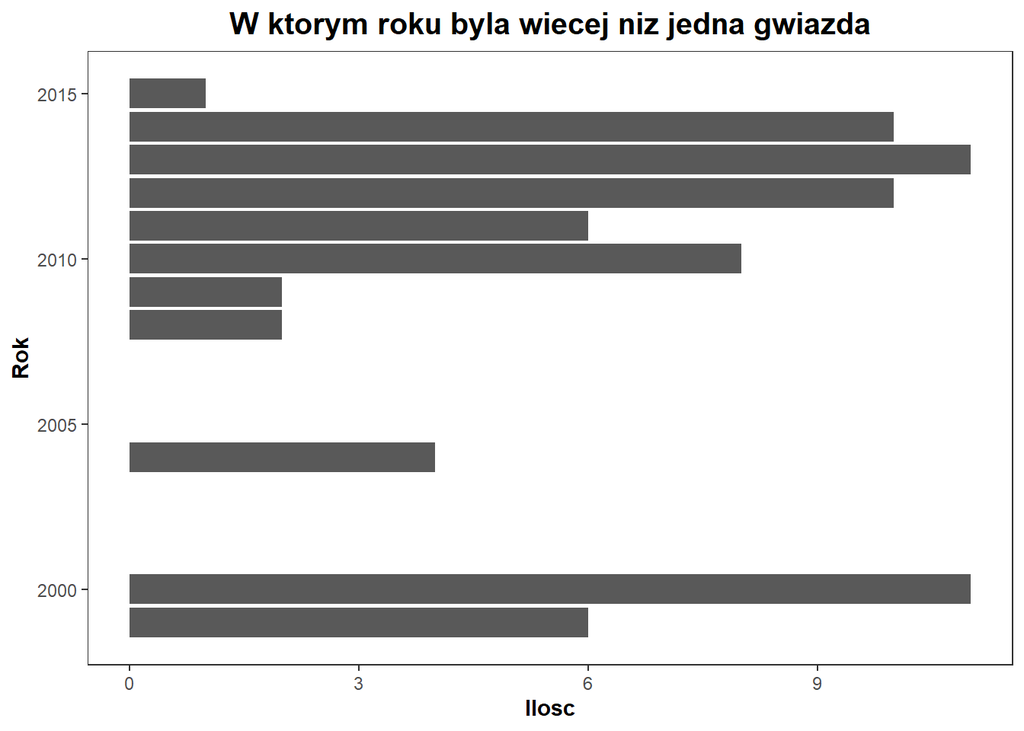

```r
Andy%>% group_by(year) %>% summarise( ilosc = n()) %>% ggplot(aes(x=year, y= ilosc)) + geom_col() +xlab("Rok") + ylab("Ilosc") +
   ggtitle("W ktorym roku byla wiecej niz jedna gwiazda")+
   theme_test() +
   theme(plot.title = element_text(size = 15, hjust=0.5, face= 'bold', margin = ))+
   theme(axis.title.x = element_text( face="bold"))+
   theme(axis.title.y= element_text( face="bold"))  + coord_flip()
```

Najwięcej wywiadów ze sławnymi ludźmi miało miejsce w latach 2000, 2012, 2013 i 2014.

## Zespoły

Znalezienie zespołów

```r
Bandy<- guests3 %>% filter(str_detect(guests3$google_knowledge_occupation, 'band' ) )
guests3<- guests3 %>% filter(!(str_detect(guests3$google_knowledge_occupation, 'band' ) ))
Bandy
```

```
## # A tibble: 13 x 7
##    google_knowledge_occupat~ group    year month   day raw_guest_list     season
##    <chr>                     <fct>   <dbl> <dbl> <dbl> <chr>              <chr>
##  1 rock band                 Musici~  1999    11    29 Goo Goo Dolls      autumn
##  2 rock band                 Musici~  2000     9    20 Barenaked Ladies   autumn
##  3 band                      Musici~  2000     9     7 Spinal Tap         autumn
##  4 rock band                 Musici~  2001     9    10 They Might Be Gia~ autumn
##  5 rock band                 Musici~  2002     4    11 The Goo Goo Dolls  spring
##  6 rock band                 Musici~  2008     6    25 Coldplay           summer
##  7 rock band                 Musici~  2009    11    19 Jack's Mannequin   autumn
##  8 band                      Musici~  2009     7    28 Spinal Tap         summer
##  9 rock band                 Musici~  2010     8    12 Arcade Fire        summer
## 10 rock band                 Musici~  2011     4    11 Foo Fighters       spring
## 11 rock band                 Musici~  2013     9    25 Atoms for Peace    autumn
## 12 rock band                 Musici~  2014    10    30 Spoon              autumn
## 13 rock band                 Musici~  2014     5    14 Blondie            spring
```

Wykres ilości zespółów w danej porze roku

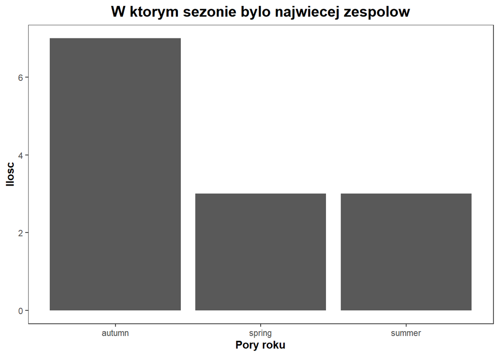

```r
Bandy%>% group_by(season) %>% summarise( ilosc = n()) %>% arrange(desc(ilosc)) %>%
   ggplot(aes(x=season, y= ilosc)) + geom_col()  +xlab("Pory roku") + ylab("Ilosc") +
   ggtitle("W ktorym sezonie bylo najwiecej zespolow")+
   theme_test() +
   theme(plot.title = element_text(size = 15, hjust=0.5, face= 'bold', margin = ))+
   theme(axis.title.x = element_text( face="bold"))+
   theme(axis.title.y= element_text( face="bold"))  +
   scale_y_continuous(breaks = seq(from = 0, to = 10,by =2 ))
```

## Imiona żeńskie i męskie

Wczytanie imion żeńskich i męskich z pliku

```r
imionaz<- read_lines("data/first-names.txt")
imionam<- read_lines("data/male-names.txt")
```

Wybranie tylko tych, które są większe niż 2

```r
imiona <- guests2  %>%  mutate(title_str = imie %>% str_replace_all("[^[:alnum:]]"," ")) %>% filter( str_length(title_str)>2)
```

Wybranie imion żeńskich

```r
imionazenskie<- imiona %>%
   unnest_tokens(output = words, input = imie ) %>%
   filter(words %in% imionaz, is.na(as.numeric(words)))
```

Wybranie imion męskich

```r
imionameskie<- imiona %>%
   unnest_tokens(output = words, input = imie ) %>%
   filter(words %in% imionam, is.na(as.numeric(words)))
```

Policzenie i wybranie 20 najbardziej popularnich imion męskich

```r
namesOccurencem <- imionameskie %>% group_by(title_str) %>% tally() %>% rename(Number_of_Occurences = n)
mostFamousm <- namesOccurencem %>% top_n(20, Number_of_Occurences) %>% arrange(desc(Number_of_Occurences))
```

Policzenie i wybranie 20 najbardziej popularnich imion żeńskich

```r
namesOccurencek <- imionazenskie %>% group_by(title_str) %>% tally() %>% rename(Number_of_Occurences = n)
mostFamousk <- namesOccurencek %>% top_n(20, Number_of_Occurences) %>% arrange(desc(Number_of_Occurences))
```

Wykres najpopularniejszych imion męskich

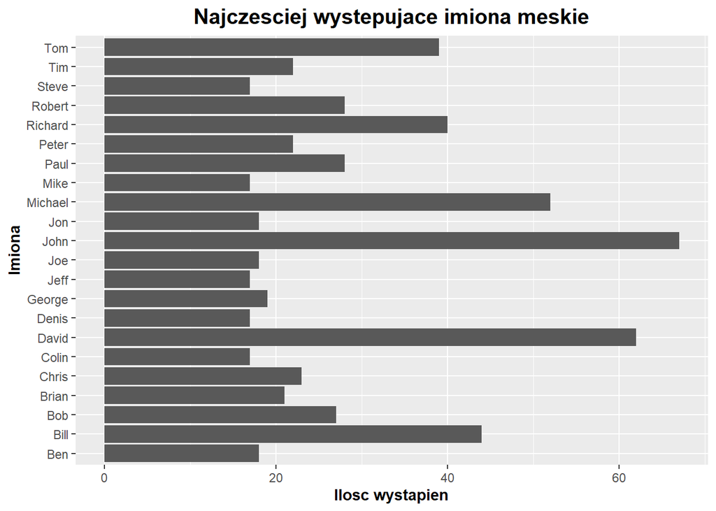

```r
namesOccurencem %>% top_n(20, Number_of_Occurences) %>% arrange(desc(Number_of_Occurences)) %>%
   ggplot(aes(x=title_str, y=Number_of_Occurences)) +
   geom_bar(stat='identity') +
   coord_flip()+
   ggtitle("Najczesciej wystepujace imiona meskie")+
   xlab("Imiona") + ylab("Ilosc wystapien") +
   theme(plot.title = element_text(size = 15, hjust=0.5, face= 'bold', margin = ))+
   theme(axis.title.x = element_text( face="bold"))+
   theme(axis.title.y= element_text( face="bold"))
```

Najczęściej występującym imieniem męskim jest John. Na drugim miejscu plasuje się David, a następnie Michael.

Wykres najpopularniejszych imion żeńskich

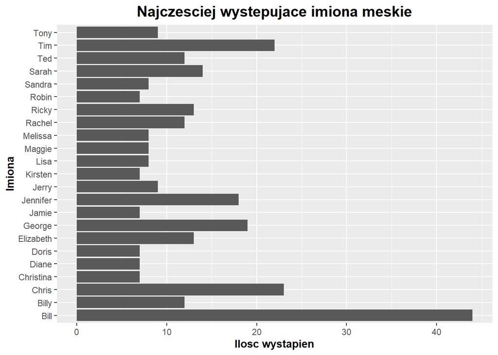

```r
namesOccurencek %>% top_n(20, Number_of_Occurences) %>% arrange(desc(Number_of_Occurences)) %>%
   ggplot(aes(x=title_str, y=Number_of_Occurences)) +
   geom_bar(stat='identity') +
   coord_flip()+
   ggtitle("Najczesciej wystepujace imiona meskie")+
   xlab("Imiona") + ylab("Ilosc wystapien")+
   theme(plot.title = element_text(size = 15, hjust=0.5, face= 'bold', margin = ))+
   theme(axis.title.x = element_text( face="bold"))+
   theme(axis.title.y= element_text( face="bold"))
```

Najpopularniejsze imiona żeńskie w wybranym zbiorze danych to Jennifer, Sarah Elizabeth oraz Rachel.

Wykres ilości kobiet w danej grupie

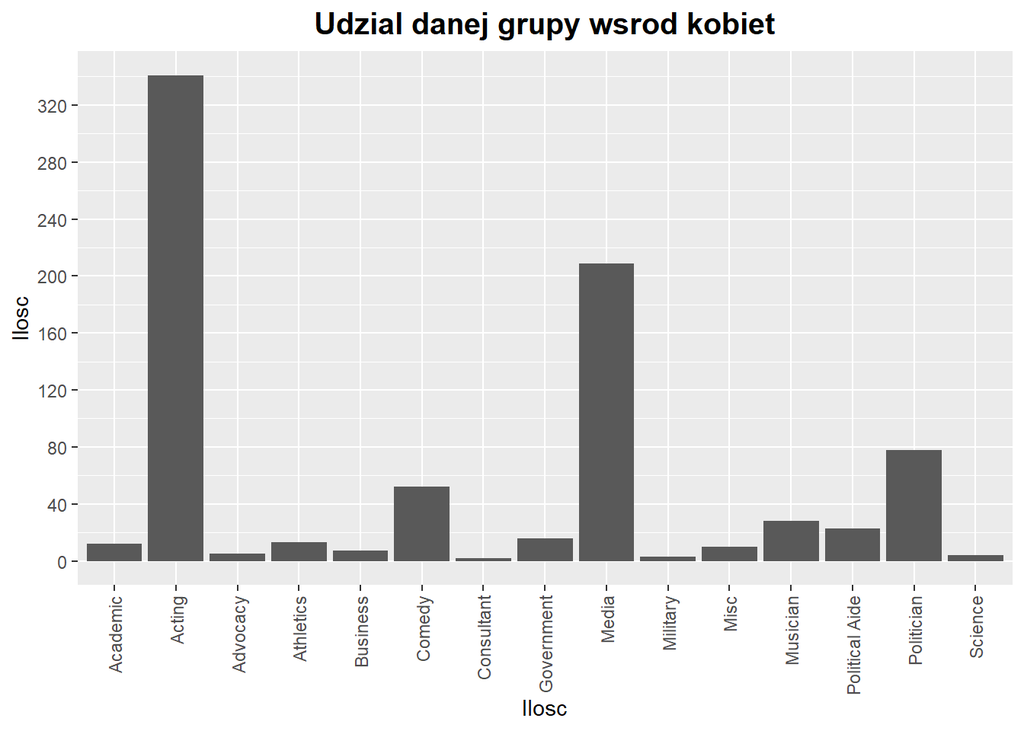

```r
imionazenskie %>% group_by(group) %>% summarise(ilosc = n()) %>% ggplot(aes(x=group, y=ilosc)) + geom_col() +
   theme(axis.text.x = element_text(angle = 90, hjust = 1, vjust = 0.5)) + xlab("Ilosc")+
   ylab("Ilosc")  +  ggtitle("Udzial danej grupy wsrod kobiet") + theme(plot.title = element_text(size = 15, hjust=0.5, face= 'bold', margin = )) + scale_y_continuous(breaks = seq(from = 0, to = 600,by =40 ))
```

Wśród kobiet najczęściej występującą grupą jest aktorstwo oraz media.

Wykres ilości mężczyzn w danej grupie

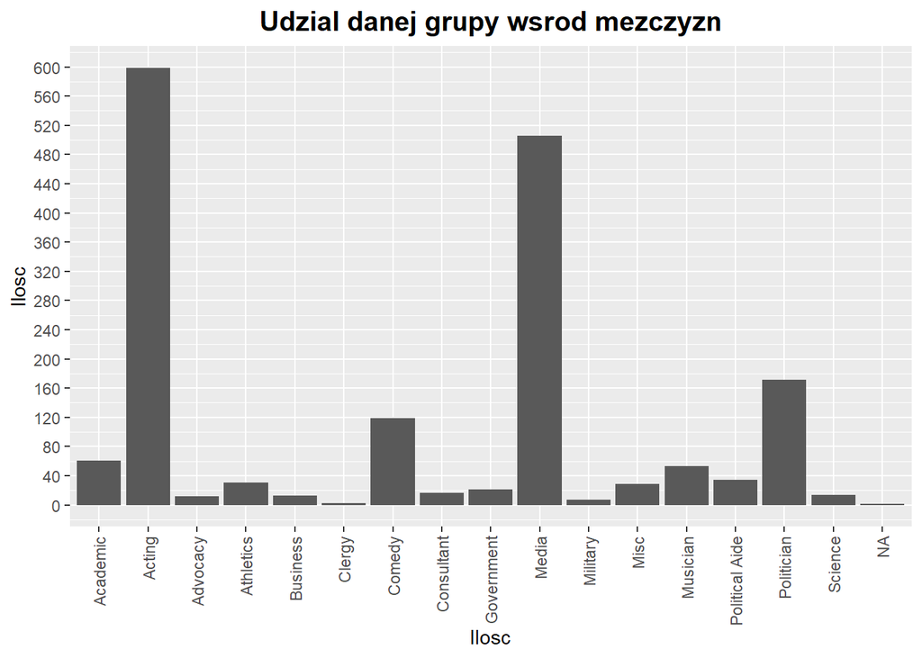

```r
imionameskie %>% group_by(group) %>% summarise(ilosc = n()) %>% ggplot(aes(x=group, y=ilosc)) + geom_col() +
   theme(axis.text.x = element_text(angle = 90, hjust = 1, vjust = 0.5)) + xlab("Ilosc")+
   ylab("Ilosc") +  ggtitle("Udzial danej grupy wsrod mezczyzn") + theme(plot.title = element_text(size = 15, hjust=0.5, face= 'bold', margin = )) + scale_y_continuous(breaks = seq(from = 0, to = 600,by =40 ))
```

Analogicznie wygląda sytuacja wśród mężczyzn, chociaż u nich udział grupy “Media” jest znacznie większy. Ogólna liczba wywiadów z udziałem mężczyzn jest również dużo większa.

Wykres kobiet w danej grupie w określonej porze roku

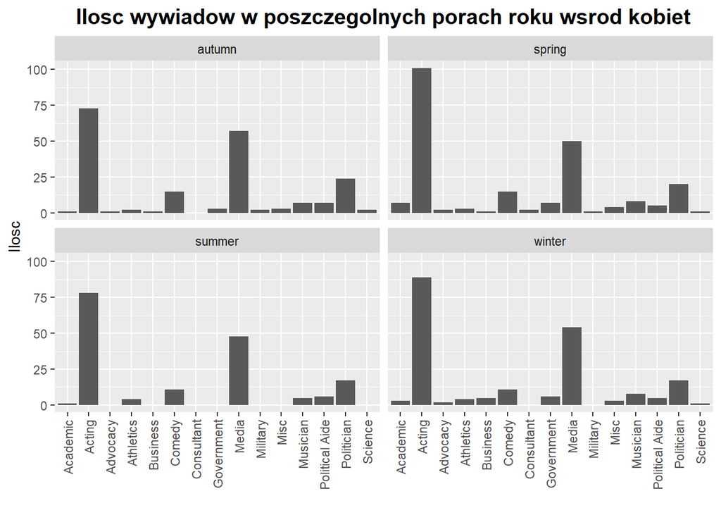

```r
ggplot(imionazenskie, aes(x=group)) + geom_bar() +
   facet_wrap(~season) + ggtitle("Ilosc wywiadow w poszczegolnych porach roku wsrod kobiet") +
   theme(plot.title = element_text(size = 15, hjust=0.5, face= 'bold', margin = ))+
   theme(axis.text.x = element_text(angle = 90, hjust = 1, vjust = 0.5)) +
   xlab("") + ylab("Ilosc")
```

Procentowy udział poszczególnych grup w różnych porach roku jest raczej podobny. Można zatem wywnioskować, iż pora roku nie wpływa na popularność danej grupy społecznej wśród widzów.

Wykres mężczyzn w danej grupie w określonej porze roku

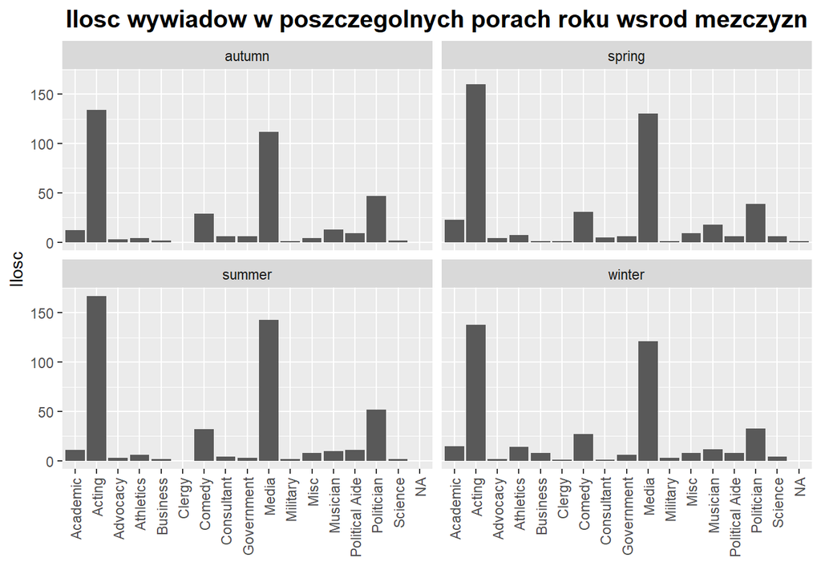

```r
ggplot(imionameskie, aes(x=group)) + geom_bar() +
   facet_wrap(~season) + ggtitle("Ilosc wywiadow w poszczegolnych porach roku wsrod mezczyzn") +
   theme(plot.title = element_text(size = 15, hjust=0.5, face= 'bold', margin = ))+
   theme(axis.text.x = element_text(angle = 90, hjust = 1, vjust = 0.5)) +
   xlab("") + ylab("Ilosc")
```

Wśród mężczyzn ta sytuacja wygląda podobnie.

Wykres różnych grup na przedziale lat

```r
df <- guests %>% group_by(group, year) %>% summarise( ilosc = n())
```

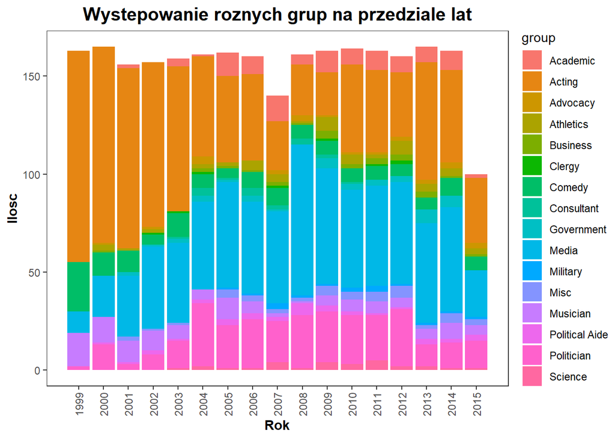

```r
#usuniecie grupy NA
df <- na.omit(df)

ggplot(df, aes(fill=group, x=year, y=ilosc)) +
   geom_bar(position="stack", stat="identity") +
   scale_x_continuous(breaks = c(1999,2000,2001,2002,2003,2004,
                                 2005,2006,2007,2008,2009,2010,2011,
                                 2012,2013,2014,2015)) +
   ggtitle("Wystepowanie roznych grup na przedziale lat")+
   xlab("Rok")+
   ylab("Ilosc") +
   theme_test() +
   theme(plot.title = element_text(size = 15, hjust=0.5,  face= 'bold', margin = ))+
   theme(axis.text.x = element_text(angle = 90, hjust = 1, vjust = 0.5)) +
   theme(axis.title.x= element_text(face="bold")) +
   theme(axis.title.y= element_text(face="bold"))
```

Od 1999 roku udział osób zajmujących się aktorstwem raczej malał na rzecz osób z grupy “Media”. Ogólna ilość wywiadów jednak pozostawała raczej niezmienna. Niewielki wyjątek miał miejsce w 2007 roku, gdy to ogólna liczba wywiadów znacznie zmalała. W roku 2015 przeprowadzono najmniejszą liczbę wywiadów, jednak było to spowodowane zakończeniem zbierania danych w trzecim kwartale roku.

## Ilość wywiadów na przestrzeni miesiąca

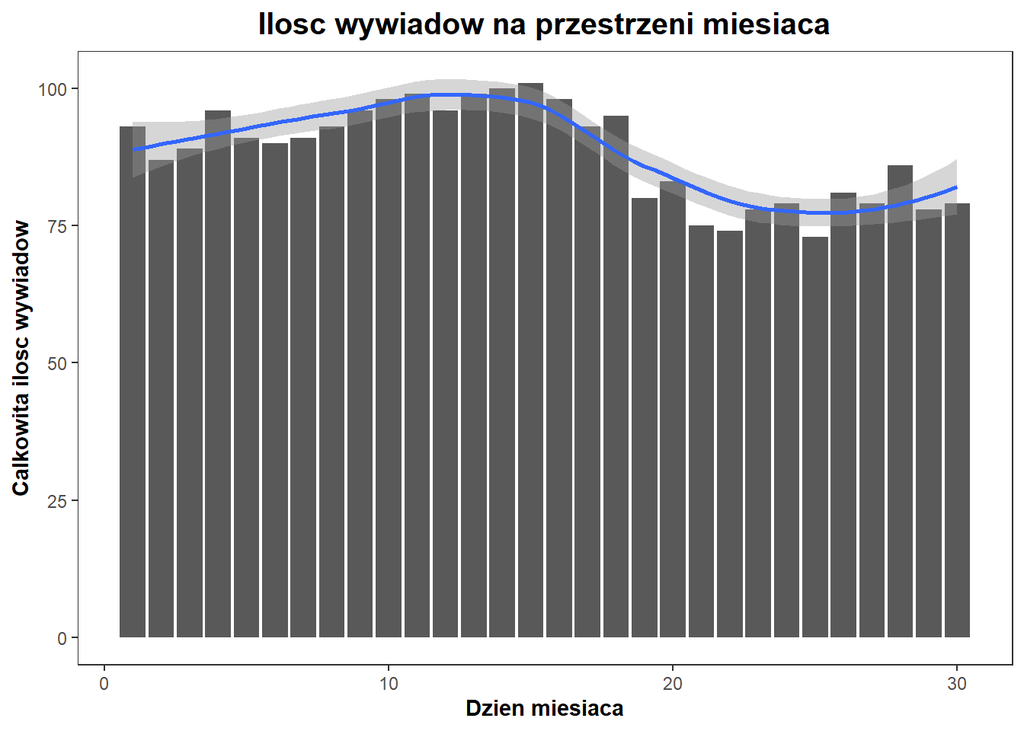

```r
frequency <- guests %>% group_by(day) %>% tally()
#Delete 31st day of month, because of distortions on the chart
#Should be [1:28] if we want to be very objective
frequency <- frequency[1:30,]
frequency %>% ggplot(aes(x=day, y=n)) + geom_bar(stat = 'identity')+geom_smooth()+
   ggtitle("Ilosc wywiadow na przestrzeni miesiaca")+
   xlab("Dzien miesiaca")+
   ylab("Calkowita ilosc wywiadow") +
   theme_test() +
   theme(plot.title = element_text(size = 15, hjust=0.5,  face= 'bold', margin = ))+
   theme(axis.title.x = element_text( face="bold"))+
   theme(axis.title.y= element_text( face="bold"))
```

Ze względu na ilość dni w różnych miesiącach usnięto 31 pierwszy dzień, ponieważ sztucznie zaniżałby on ostatnie wskazanie na wykresie. Co prawda luty posiada 28 lub 29 dni, jednak jest to jedyny taki miesiąc w roku, dlatego ustawiony przedział wynosi 30 dni.

Z wykresu wynika, że większość wywiadów jest przeprowadzana w pierwszych 20 dniach miesiąca.

## Ilość wywiadów na przestrzeni tygodnia

Dzięki wykorzystaniu funkcji z pakietu Lubridate mogły zostać określone poszczególne dni tygodnia w jakich przeprowadzane były wywiady.

```r
interviewDate <- daily_show_guests
interviewDate <- interviewDate %>% add_column(guests$month, guests$day)

#dplyr::rename z powodu konfliktu z plyr
interviewDate <- dplyr::rename(interviewDate, month=`guests$month`, day=`guests$day`, date=`show`)
interviewDate <- interviewDate[,c(1,3,6,7)]

interviewDate$textMonth <- as.yearmon(interviewDate$date)
interviewDate$textMonthF <- factor(interviewDate$textMonth)
interviewDate$dayInYear <- as.Date(interviewDate$date,format='%Y-%m-%d')
interviewDate$dayInYear <- lubridate::yday(interviewDate$dayInYear)
interviewDate$weekDay <- weekdays(interviewDate$date)
interviewDate$weekNumber <- strftime(interviewDate$date, format = "%V")
interviewDate <- ddply(interviewDate,.(textMonthF),transform)

topDay <- interviewDate %>% group_by(weekDay) %>% tally()
orderDays <- c("Monday", "Tuesday", "Wednesday", "Thursday", "Friday", "Sunday")

topDay <- topDay[match(orderDays, topDay$weekDay),]
topDay
```

```
## # A tibble: 6 x 2
##   weekDay       n
##   <chr>     <int>
## 1 Monday      623
## 2 Tuesday     689
## 3 Wednesday   693
## 4 Thursday    678
## 5 Friday        9
## 6 Sunday        1
```

Na podstawie powyższych danych można zauważyć, że wywiady w piątki i niedziele to prawdziwa rzadkość. W niedzielę miał miejsce tylko jeden wywiad. Ciekawy jest również fakt, iż żaden z wywiadów nie został przeprowadzony w sobotę.

## Ilość wywiadów w poszczególnych miesiącach

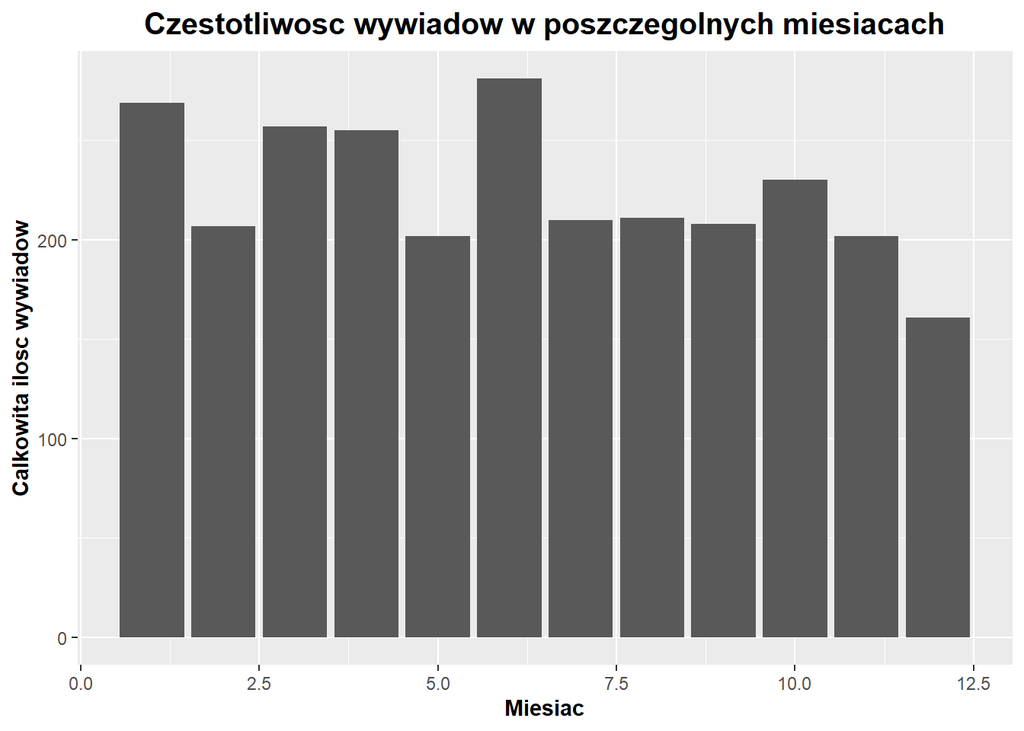

```r
monthlyFrequency <- interviewDate %>% group_by(month) %>% tally()
monthlyFrequency %>% ggplot(aes(x=month, y=n)) + geom_bar(stat = 'identity') +
   ggtitle("Czestotliwosc wywiadow w poszczegolnych miesiacach") +
   xlab("Miesiac")+
   ylab("Calkowita ilosc wywiadow") +
   theme(plot.title = element_text(size = 15, hjust=0.5, face= 'bold', margin = ))+
   theme(axis.title.x = element_text( face="bold"))+
   theme(axis.title.y= element_text( face="bold"))
```

Na podstawie powyższego wykresu można zauważyć, że pod koniec roku przeprowadzana jest mniejsza ilość wywiadów.

## Ilość wywiadów w poszczególnych latach

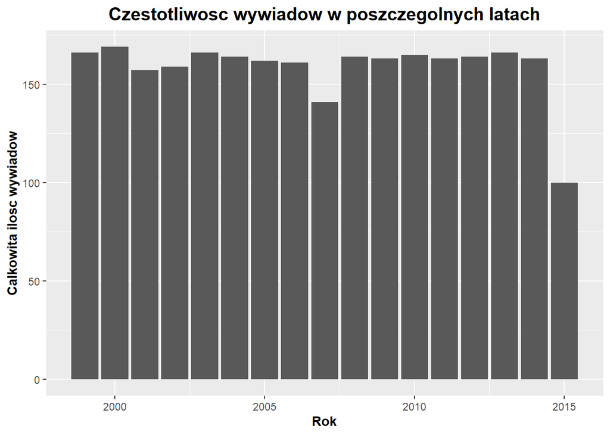

```r
yearFrequency <- interviewDate %>% group_by(year) %>% tally()
yearFrequency %>% ggplot(aes(x=year, y=n)) + geom_bar(stat = 'identity') +
   ggtitle("Czestotliwosc wywiadow w poszczegolnych latach") +
   xlab("Rok")+
   ylab("Calkowita ilosc wywiadow")+
   theme(plot.title = element_text(size = 15, hjust=0.5, face= 'bold', margin = ))+
   theme(axis.title.x = element_text( face="bold"))+
   theme(axis.title.y= element_text( face="bold"))
```

Na podstawie powyższego wykresu można zauważyć, że w roku 2015 przeprowadzono zdecydowanie mniej wywiadów. Jako że jest to ostatni rok uwzględniony w zbiorze danych można spodziewać się, że zbieranie danych zostało przerwane nie wraz z końcem roku, a w jego trakcie. Zostało to sprawdzone w trakcie wykonywania projektu - ostatni wywiad odbył się 5 sierpnia 2015 roku, co potwierdza powyższe przypuszczenia.

## Ilość wywiadów w przeciągu roku

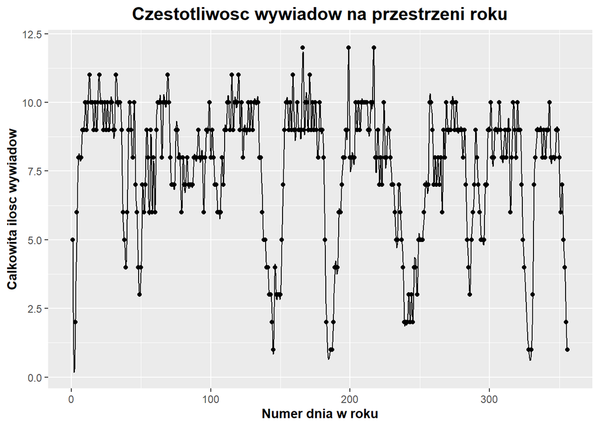

```r
allFrequency <- interviewDate %>% group_by(dayInYear) %>% tally()

spline.d <- as.data.frame(spline(allFrequency$dayInYear, allFrequency$n))
allFrequency %>% ggplot(aes(x=dayInYear, y=n)) + geom_point() + geom_line(data = spline.d, aes(x = x, y = y)) +
   ggtitle("Czestotliwosc wywiadow na przestrzeni roku") +
   theme(plot.title = element_text(size = 15, hjust=0.5, face= 'bold', margin = ))+
   xlab("Numer dnia w roku")+
   ylab("Calkowita ilosc wywiadow")+
   theme(plot.title = element_text(size = 15, hjust=0.5, face= 'bold', margin = ))+
   theme(axis.title.x = element_text( face="bold"))+
   theme(axis.title.y= element_text( face="bold"))
```

Jeśli w danym dniu przeprowadzane są wywiady, to zazwyczaj jest ich 7-10 dziennie. Kilkukrotnie w ciągu roku można zaobserwować większe spadki. Po wyliczeniu numeru dnia okazuje się, że spadki występują:

- na początku stycznia
- pod koniec maja
- na początku lipca
- pod koniec sierpnia
- pod koniec listopada
- pod koniec roku.

Po porównaniu tych dat, okazuje się, że pokrywają one się w dużej mierze ze świętami w Stanach Zjednoczonych. O ile początek i koniec roku nie powinien nikogo dziwić, to okazuje się, że pod koniec maja w USA ma miejsce Memorial Day. Czwartego lipca ma miejsce Święto Niepodległości, a pod koniec listopada Święto Dziękczynienia. Niestety nie byliśmy w stanie znaleźć żadnego sensownego wytłumaczenia sierpniowego spadku.

Podczas liczenia numeru dnia w roku został uwzględniony 29 luty.

## Wnioski

Na podstawie powyższych danych można przypuszczać, że wywiady zostały przeprowadzane w Stanach Zjednoczonych. Oczywiście można to sprawdzić bezpośrednio wyszukując informacje o zbiorze daily_show_guests. Ciekawy jest jednak fakt, iż można się tego dowiedzieć nie mając wiedzy skąd dane pochodzą.

Największym problemem było rzetelne podzielenie osób według ich imion. W tym celu do projektu zostały dodane dwa pliki tekstowe zawierające imiona męskie i żeńskie, dzięki czemu można było sprawdzić, do jakiej grupy należy przyporządkować konkretną osobę.

Początkowo ciężko było wyłuskać większą ilość sensownych informacji z tak skąpego zbioru danych. Znajdowały się w nim wyłącznie daty wywiadów, imiona i nazwiska osób biorących w nich udział, zawód i grupę do jakiej dany zawód może być przypisany. Jednak w miarę postępów w projekcie, zauważaliśmy coraz więcej możliwych informacji do wyłuskania. Informacja o braku wywiadów w soboty oraz niewielkiej ilości wywiadów w piątki i niedziele była dla nas zaskoczeniem i dowiedzieliśmy się tego podczas analizy danych w zupełnie innym celu. Podobnie jak i powiązanie spadków ilości wywiadów w ciągu roku ze świętami w Stanach Zjednoczonych.

Dalsza analiza danych mogła by się opierać o dodatkowe zbiory danych, posiadające więcej informacji o gościach programu. W takiej sytuacji możnaby analizować miejsca ich zamieszkania, daty urodzenia, czy stan cywilny.